# Visual Analytics

## 1 TODO Tutorial

### 1.1 TODO Question 1

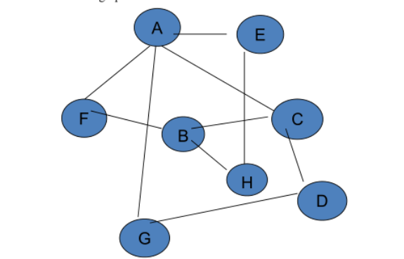

Figure 1: Graph to Fix

#### 1.1.1 Possible Improvements

1. minimizing the intersectoin of edges
2. Using Colours to show the distinction between nodes

#### 1.1.2 Generated DOT Graph

The easiest way to generate graph is to use the DOT library with *[PlantUML](https://plantuml.com/download)*:

**Expand Code **Click Here**

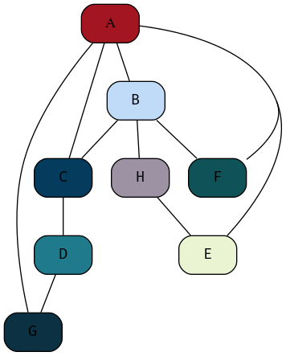

```javascript
@startdot
strict digraph graphName {
concentrate=true
fillcolor=green
color=blue
style="filled, rounded"
 A [shape=box, fillcolor="#a31621", style="rounded, filled"]

 edge [
    arrowhead="none"
  ];

 node[
    fontname="Fira Code",
    shape="square",
    fixedsize=false,
    style=rounded
  ];


# A -> B [dir="both"]
A -> B
A -> C
A -> G
B [shape=box, fillcolor="#bfdbf7", style="rounded, filled"]
B -> F
B -> C
B -> H
B -> H
C [shape=box, fillcolor="#053c5e", style="rounded, filled"]
C -> A
C -> B
C -> D
D [shape=box, fillcolor="#1f7a8c", style="rounded, filled"]
D -> G
D -> C
E [shape=box, fillcolor="#eaf4d3", style="rounded, filled"]
E -> H
E -> A
F [shape=box, fillcolor="#0f5257", style="rounded, filled"]
F -> A
F -> B
G [shape=box, fillcolor="#0b3142", style="rounded, filled"]
G -> A
G -> D
H [shape=box, fillcolor="#9c92a3", style="rounded, filled", arrowType="dot"]
H -> E [arrowType="dot"]
H -> B
}
@enddot
```

Figure 2: DOT graph created using PlantUML

#### 1.1.3 Sequence Diagram

Plant UML can also create a sequence diagram which is a different type of visualisation but is still an interesting way to visualise the relationships.

```javascript
@startuml
    A-->B
    A-->C
    A-->G
    B-->F
    B-->C
    B-->H
    B-->H
    C-->A
    C-->B
    C-->D
    D-->G
    D-->C
    E-->H
    E-->A
    F-->A
    F-->B
    G-->A
    G-->D
    H-->E
    H-->B
@enduml
```

[output not shown]

### 1.2 Question 2

> Explore and find 3 good and 3 bad examples of graphs on the Internet, including a justification for each example.

#### 1.2.1 Good Examples

1. Solar Winds

[figure not shown]

   Figure 3: Exemplar plot for Solar Winds product
2. Standord Paper Visualisation

   The Proceeding Plot shown in figure 4 is a graph showing feature construction in a paper written at (McAuley and Leskovec, n.d.) presumably produced in TikZ, it is an effective graph because:
   - the colours to denote the two main discrete variables are distinct
   - The edges don't overlap
   - The Nodes tesalate in a way that makes the graph easy to read
   - Where a quasi-node is used to branch an edge to facilitate node tesallation it is denoted by a slight bulge making it clear to delineate the edges

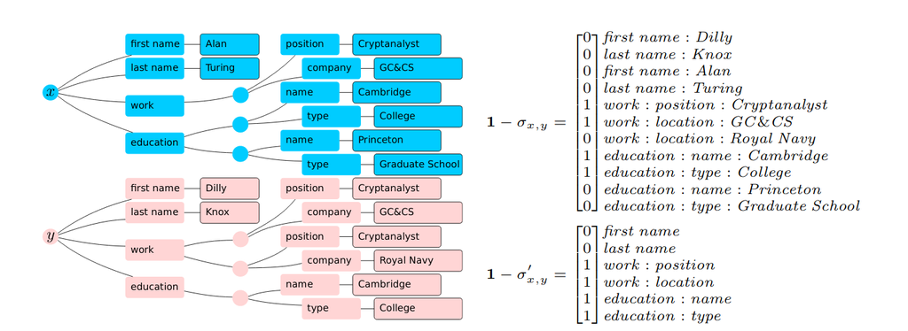

[figure not shown]

#### 1.2.2 Bad Examples

1. igraph Library Example

   The following plot shown in figure 6 from the [*R* graph gallery](https://www.r-graph-gallery.com/250-correlation-network-with-igraph.html)<sup>2</sup> is bad example of a graph because the edges are hard to discern the labels are not clearly delineated, the edges cross over unnecessarily and the thickness of the edges is too small

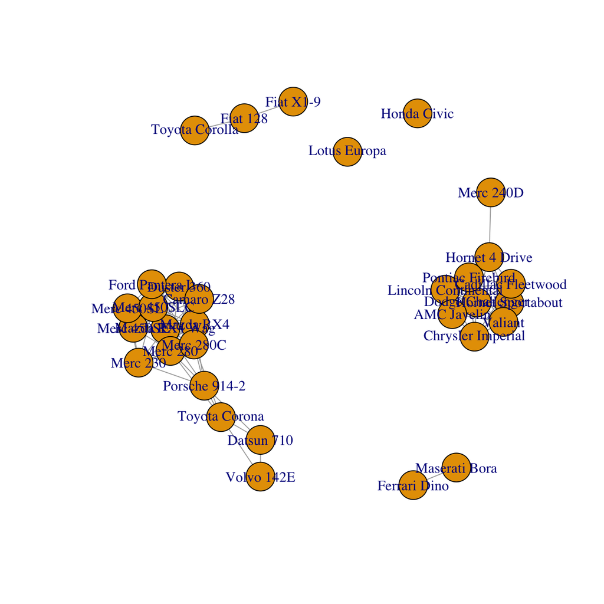

   Figure 6: Correlation Network Diagram of `mtcars` data
2. Research chronology

   The proceeding graph is an exemplar plot of a service known as [Research Chronology](http://www.datadreamer.com/item/research2)<sup>3</sup>.

   It is a poor graph because:
   - There are too many overlaps between edges
   - There are too many colours to uniquely identify the discrete variables
   - The plot needs to be further spaced

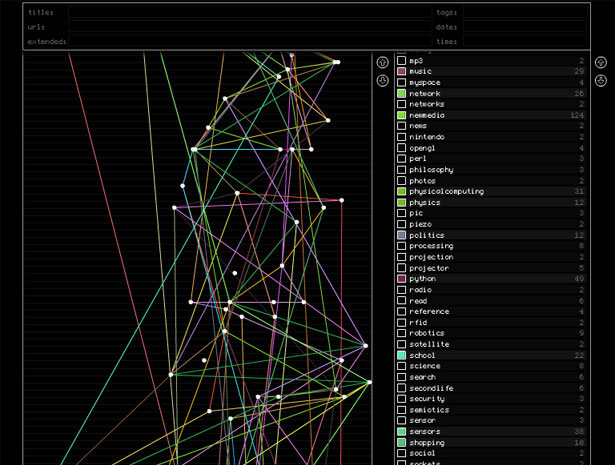

   Figure 7: Graph Depiction of research chronology
3. Mapping the BlogoSphere

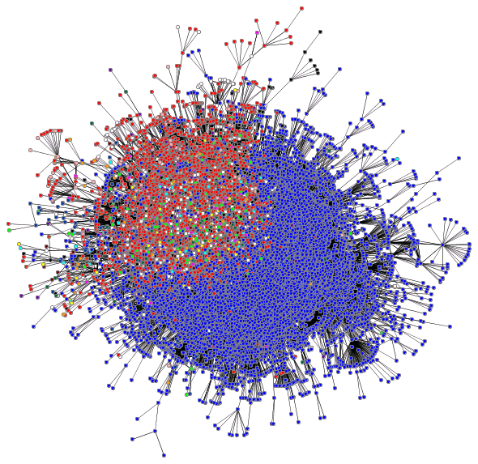

### 1.3 TODO Question 3

> What is a tree structure? Provide 3 examples of a tree structure in real life.

A tree structure is a general type of general graph, it will contain no cycles and will tend to have edges with direction, there will be a special designated root vertex.

#### 1.3.1 File System

The most natural type of tree structure is the directory structure of a a computer, for example the tree structure of the provided `DOI_Tree` can be visualised

```bash
cd ~/Dropbox/Studies/2020Autumn/Visual_Analytics/03_Material/Lecture3Materials4Students/DOI_Tree
tree
```

```
.
├── Data
│   ├── 2811.xml
│   ├── 3137_filesystem.xml
│   ├── 6814_filesystem.xml
│   ├── CategoryAustralia_6254.txt
│   ├── CategoryAustralia_6254.xml
│   ├── CategoryAustralia.xlsx
│   ├── CategoryUSA_20289.xml
│   ├── CategoryUSA.txt
│   ├── CategoryUSA.xlsx
│   ├── Safety events ontology New.txt
│   ├── Safety events ontology New.xml
│   └── treeml.dtd
├── data.xml
├── DOITreeVis.jar
├── META-INF
│   └── MANIFEST.MF
└── ReadMe.txt

2 directories, 16 files
```

#### 1.3.2 Tree Machine Learning Technique

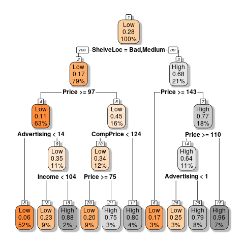

```r
  library(tree)
  library(tidyverse)

  if(require('pacman')){
    library('pacman')
  }else{
    install.packages('pacman')
    library('pacman')
  }

  pacman::p_load(caret, scales, ggplot2, rmarkdown, shiny, ISLR, class, BiocManager, corrplot, plotly, tidyverse, latex2exp, stringr, reshape2, cowplot, ggpubr, rstudioapi, wesanderson, RColorBrewer, colorspace, gridExtra, grid, car, boot, colourpicker, tree, ggtree, mise, rpart, rpart.plot, knitr, MASS, magrittr)

  CSeat.tb <- as_tibble(Carseats)


  thresh <- (mean(CSeat.tb$Sales)+0.5*sd(CSeat.tb$Sales)) %>% round()
  CSeat.tb$CatSales <- ifelse(CSeat.tb$Sales > thresh, "High", "Low")
  CSeat.tb$CatSales <- factor(x = CSeat.tb$CatSales, levels = c("Low", "High"), ordered = TRUE)
  CSeat.tb <- CSeat.tb[,c(12, 2:11)]

CatSalesModTree.rpart <- rpart(formula = CatSales ~ ., data = CSeat.tb)
rpart.plot(CatSalesModTree.rpart, box.palette="OrGy", shadow.col="gray", nn=TRUE)
```

Figure 9: Example of Tree Plot using Built in Data

#### 1.3.3 Genetic Lineage

Genetic Lineage is another example of a tree structure graph, for example a the tree of life would look something to the effect of:

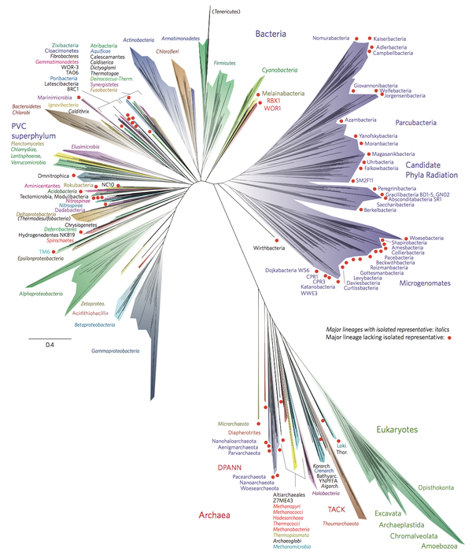

Figure 10: Example of Tree of life

### 1.4 TODO Question 4

> Explore the tree visualization techniques at http://treevis.net/ . Identify 10 connection (node-linked diagram) techniques and 10 enclosure techniques.

#### 1.4.1 Techniques using connections or node links are:

1. Generalized Pythagoras Trees (2014) by Fabian Beck
   - https://doi.org/10.5220/0004654500170028
2. [StackTree Layout](https://treevis.net/#Miller2011)
3. [Career Tree](https://treevis.net/#Bocoup2011)
4. [Ordered Tree Drawing](https://treevis.net/#Brunner2010)
5. [GeoReferenced Tree Layout](https://treevis.net/#Parks2009)
6. [Rhizome Navigation](https://treevis.net/#Rafelsberger2007)
7. [Quadratic Programming Layout](https://treevis.net/#Bohanec2007)
8. [Clustergram](https://treevis.net/#Schonlau2002)
9. [Perspective Mapping](https://treevis.net/#Bowers1996)
10. [Planar Upward Drawing](https://treevis.net/#Garg1996)

#### 1.4.2 Techniques using Enclosure Techniques include

1. [Mixed Projection Treemap](https://treevis.net/#Limberger2017)
2. [Bubble Treemap](https://treevis.net/#Goertler2018)
3. [Stable Treemap](https://treevis.net/#Sondag2018)
4. [Hybrid Treemap](https://treevis.net/#Hahn2017)
5. [Columnar Treemap](https://treevis.net/#Armitage2014)
6. [Heirarchy map](https://treevis.net/#Aborisade2010)
7. [Word Treemap](https://treevis.net/#Feinberg2010)
8. [3D-Treemap](https://treevis.net/#Liggesmeyer2009)
9. [Circular Treemap](https://treevis.net/#Onak2008)
10. [Eichhorn Tree](https://treevis.net/#Eichhorn2006)

### 1.5 TODO Question 5

> Explore the visualizations of Treemap, DOI<sub>Tree</sub> and D&CTreemap from the demo systems. In your opinion, give the pros and cons of each technique.

Personal note, thank you so much for making these simple `.jar` files rather than `.exe`'s I hate using wine and I'm glad these are cross platform applications.

#### 1.5.1 Treemap

> file:///home/ryan/Dropbox/Studies/2020Autumn/Visual_Analytics/03_Material/Lecture3Materials4Students/Treemap-4.0.5/Monitor.jar

The UI is very mouse heavy which makes it difficult to manipulate, the UI is also a little busy.

Overall though being able to double click through the enclosed regions to move through the bins and being able to change the partitioning method from strip to slice and dice makes it easy to manipulate.

#### 1.5.2 DOI<sub>Tree</sub>

> file:///home/ryan/Dropbox/Studies/2020Autumn/Visual_Analytics/03_Material/Lecture3Materials4Students/DOI_Tree/DOITreeVis.jar

Unfourtanetly I was unable to load the built in data sets I had created without having a crash, this was the output regardless:

[output not shown]

So overall I would say that a definite downside to this tool is that it is a little unstable (or very possibly I'm using the wrong java, I'm just using whatever my distro shipped with)

#### 1.5.3 D&C Treemap

> file:///home/ryan/Dropbox/Studies/2020Autumn/Visual_Analytics/03_Material/Lecture3Materials4Students/D&CTreemap/DCTreemap.jar

[figure not shown]

Figure 11: DCTreemap

## 2 References

## Bibliography

McAuley, Julian, and Jure Leskovec. n.d. “Learning to Discover Social Circles in Ego Networks,” 9.

## Footnotes:

<sup>1</sup>

https://www.solarwinds.com/network-performance-monitor/use-cases/network-visualization

<sup>2</sup>

https://www.r-graph-gallery.com/250-correlation-network-with-igraph.html

<sup>3</sup>

http://www.datadreamer.com/item/research2

Author: Ryan G

Created: 2020-03-25 Wed 19:38

[Validate](http://validator.w3.org/check?uri=referer)